# Homework - solution

## 4 - R Markdown

## 4.3

### 4.3.1

Print the summary of the `penguins` dataset from the `palmerpenguins` R package using `knitr::kable`. How many observations are there? How many different species of penguins?

```r
library(palmerpenguins)
library(ggplot2)
```

```r
knitr::kable(summary(penguins))
```

|  | species | island | bill_length_mm | bill_depth_mm | flipper_length_mm | body_mass_g | sex | year |
| --- | --- | --- | --- | --- | --- | --- | --- | --- |
|  | Adelie :152 | Biscoe :168 | Min. :32.10 | Min. :13.10 | Min. :172.0 | Min. :2700 | female:165 | Min. :2007 |
|  | Chinstrap: 68 | Dream :124 | 1st Qu.:39.23 | 1st Qu.:15.60 | 1st Qu.:190.0 | 1st Qu.:3550 | male :168 | 1st Qu.:2007 |
|  | Gentoo :124 | Torgersen: 52 | Median :44.45 | Median :17.30 | Median :197.0 | Median :4050 | NA’s : 11 | Median :2008 |
|  | NA | NA | Mean :43.92 | Mean :17.15 | Mean :200.9 | Mean :4202 | NA | Mean :2008 |
|  | NA | NA | 3rd Qu.:48.50 | 3rd Qu.:18.70 | 3rd Qu.:213.0 | 3rd Qu.:4750 | NA | 3rd Qu.:2009 |
|  | NA | NA | Max. :59.60 | Max. :21.50 | Max. :231.0 | Max. :6300 | NA | Max. :2009 |
|  | NA | NA | NA’s :2 | NA’s :2 | NA’s :2 | NA’s :2 | NA | NA |

### 4.3.2

Order the dataset by `bill_length_mm` (ascending) and print the top 7 lines and the bottom 4 lines using `knitr::kable`.

```r
penguins_ordered <- dplyr::arrange(penguins, bill_length_mm)
knitr::kable(rbind(head(penguins_ordered,n=7),tail(penguins_ordered,n=4)))
```

| species | island | bill_length_mm | bill_depth_mm | flipper_length_mm | body_mass_g | sex | year |
| --- | --- | --- | --- | --- | --- | --- | --- |
| Adelie | Dream | 32.1 | 15.5 | 188 | 3050 | female | 2009 |
| Adelie | Dream | 33.1 | 16.1 | 178 | 2900 | female | 2008 |
| Adelie | Torgersen | 33.5 | 19.0 | 190 | 3600 | female | 2008 |
| Adelie | Dream | 34.0 | 17.1 | 185 | 3400 | female | 2008 |
| Adelie | Torgersen | 34.1 | 18.1 | 193 | 3475 | NA | 2007 |
| Adelie | Torgersen | 34.4 | 18.4 | 184 | 3325 | female | 2007 |
| Adelie | Biscoe | 34.5 | 18.1 | 187 | 2900 | female | 2008 |
| Chinstrap | Dream | 58.0 | 17.8 | 181 | 3700 | female | 2007 |
| Gentoo | Biscoe | 59.6 | 17.0 | 230 | 6050 | male | 2007 |
| Adelie | Torgersen | NA | NA | NA | NA | NA | 2007 |
| Gentoo | Biscoe | NA | NA | NA | NA | NA | 2009 |

### 4.3.3

Do a scatter plot (using the package `ggplot2`) of `bill_length_mm` (x-axis) vs. `bill_depth_mm` (y-axis).

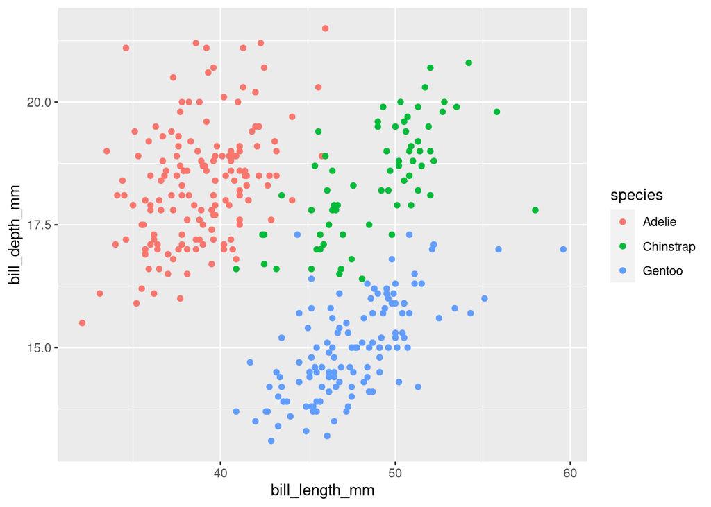

```r
ggplot(penguins) +
  geom_point(aes(bill_length_mm,bill_depth_mm,color=species))
```

### 4.3.4

Fit a linear model (use `lm`) with `bill_length_mm` as a predictor and `bill_depth_mm` as the response. Add the fitted linear relationship to the plot from the previous exercise and display the new plot. Is there an association between `bill_length_mm` and `bill_depth_mm`? What is the sign of the slope?

```r
lmfit1 <- summary(lm(bill_depth_mm ~ bill_length_mm, penguins))
lmfit1
```

```
##
## Call:
## lm(formula = bill_depth_mm ~ bill_length_mm, data = penguins)
##
## Residuals:
##     Min      1Q  Median      3Q     Max
## -4.1381 -1.4263  0.0164  1.3841  4.5255
##
## Coefficients:
##                Estimate Std. Error t value Pr(>|t|)
## (Intercept)    20.88547    0.84388  24.749  < 2e-16 ***
## bill_length_mm -0.08502    0.01907  -4.459 1.12e-05 ***
## ---
## Signif. codes:  0 '***' 0.001 '**' 0.01 '*' 0.05 '.' 0.1 ' ' 1
##
## Residual standard error: 1.922 on 340 degrees of freedom
##   (2 observations deleted due to missingness)
## Multiple R-squared:  0.05525,    Adjusted R-squared:  0.05247
## F-statistic: 19.88 on 1 and 340 DF,  p-value: 1.12e-05
```

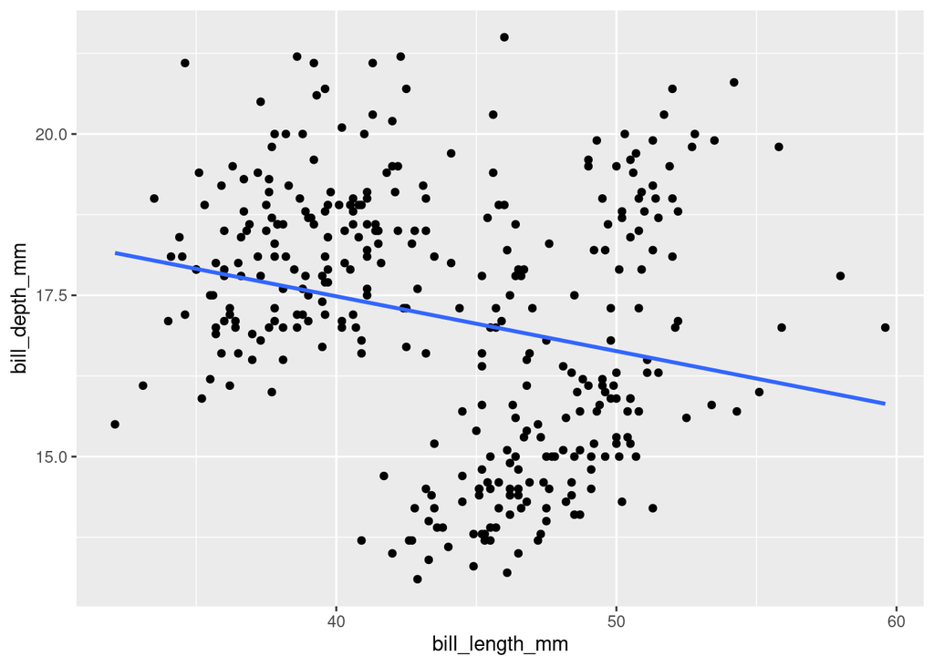

```r
ggplot(penguins) +
  geom_point(aes(bill_length_mm,bill_depth_mm)) +
  geom_smooth(aes(bill_length_mm,bill_depth_mm),method = "lm", se = FALSE)
```

### 4.3.5

Color the points from the plot from the previous plot according to species. Describe your observations.

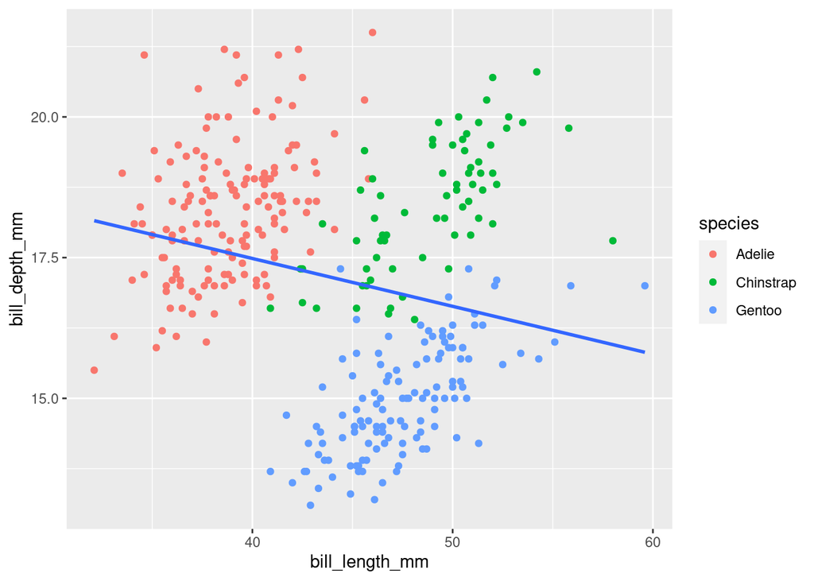

```r
ggplot(penguins) +
  geom_point(aes(bill_length_mm,bill_depth_mm,color=species)) +
  geom_smooth(aes(bill_length_mm,bill_depth_mm),method = "lm", se = FALSE)
```

### 4.3.6

Add `species` as a predictor to your model and replot the previous plot with the new regression lines (there should be three, one for each species). Is there an association between `bill_length_mm` and `bill_depth_mm`? What is the sign of the slope?

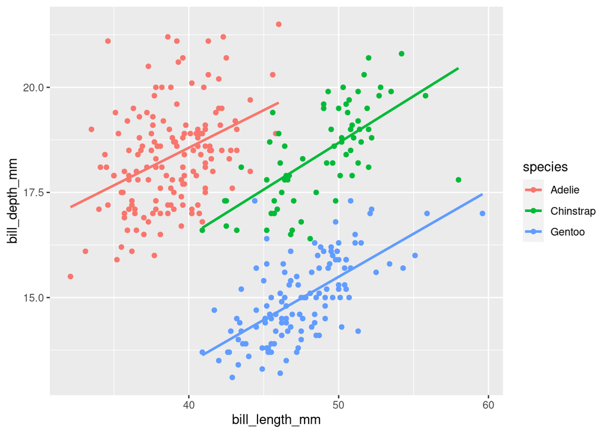

```r
lmfit2 <- summary(lm(bill_depth_mm ~  bill_length_mm + species, penguins))
ggplot(penguins) +
  geom_point(aes(bill_length_mm,bill_depth_mm,color=species)) +
  geom_smooth(aes(bill_length_mm,bill_depth_mm,color=species),method = "lm", se = FALSE)
```